# Example of making a visualization

[Sabine Loos](https://sabine-loos.com)

2020-03-19

I knew I needed to show that we have a lot of maps on damage that come out after a disaster. So I scraped the website, ReliefWeb, to download all the maps produced after a disaster.

# 1 Load necessary packages and data

```r
rm(list=ls(all = T))
library(ggplot2) # one of the best plotting tools around
library(dplyr) # to clean and tidy data
library(scales) # for color palettes (rcolorbrewer is good here too)
```

Load the data on maps. This data was scraped from Reliefweb on 27 June 2019

```r
data_rw <- readRDS("data/data_rw_062719.rds")
```

# 2 Explore data

What’s in this dataset? Look at the heading to find out:

```r
head(data_rw)
```

| website | date | country | year |
| --- | --- | --- | --- |
| ReliefWeb | 2018-11-16 | Indonesia | 2018 |
| ReliefWeb | 2018-10-22 | Indonesia | 2018 |
| ReliefWeb | 2018-10-15 | Indonesia | 2018 |
| ReliefWeb | 2018-10-09 | Indonesia | 2018 |
| ReliefWeb | 2018-10-04 | Indonesia | 2018 |
| ReliefWeb | 2018-10-04 | Indonesia | 2018 |

Looks like it shows what website the map was scraped from, the date that map was posted on that website, and the country it pertains to.

How many maps do we have? Seems to be 520 maps.

```r
dim(data_rw)
```

```
## [1] 520   4
```

## 2.1 Plot maps by year

Create a bar chart of the number of maps posted on reliefweb per year

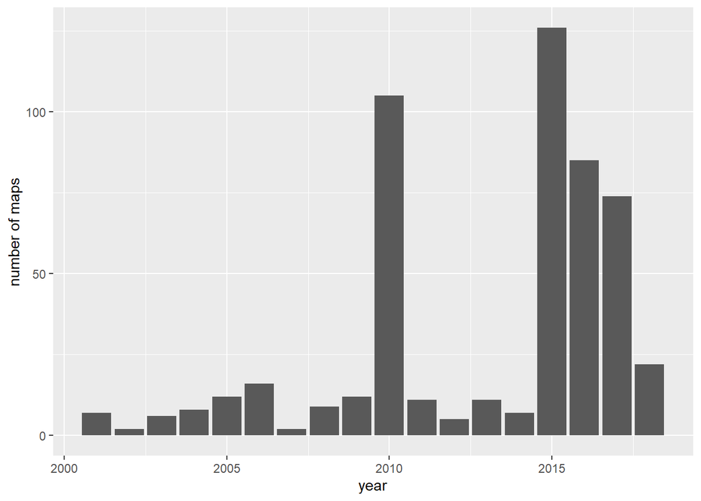

```r
ggplot(data_rw) + geom_bar(aes(x = year)) + labs(x = "year", y = "number of maps")
```

Interesting… seems like there was a huge bump in 2010 and 2015. Let’s see why.

## 2.2 Break down bar chart by country

```r
## use dplyr to calculate the percentage of each year per country
perc_rw <- data_rw %>%
  count(year, country) %>%    #count number in each group
  group_by(year)%>% # Group by region and species, then
  mutate(pct=n/sum(n),               # Calculate percent within each region
         ypos = cumsum(n))  # Calculate label positions

head(perc_rw)
```

| year | country | n | pct | ypos |
| --- | --- | --- | --- | --- |
| 2001 | El Salvador | 2 | 0.2857143 | 2 |
| 2001 | India | 3 | 0.4285714 | 5 |
| 2001 | Indonesia | 1 | 0.1428571 | 6 |
| 2001 | Peru | 1 | 0.1428571 | 7 |
| 2002 | Afghanistan | 1 | 0.5000000 | 1 |
| 2002 | Philippines | 1 | 0.5000000 | 2 |

Now I’m able to color the bar chart by the percentage for each country

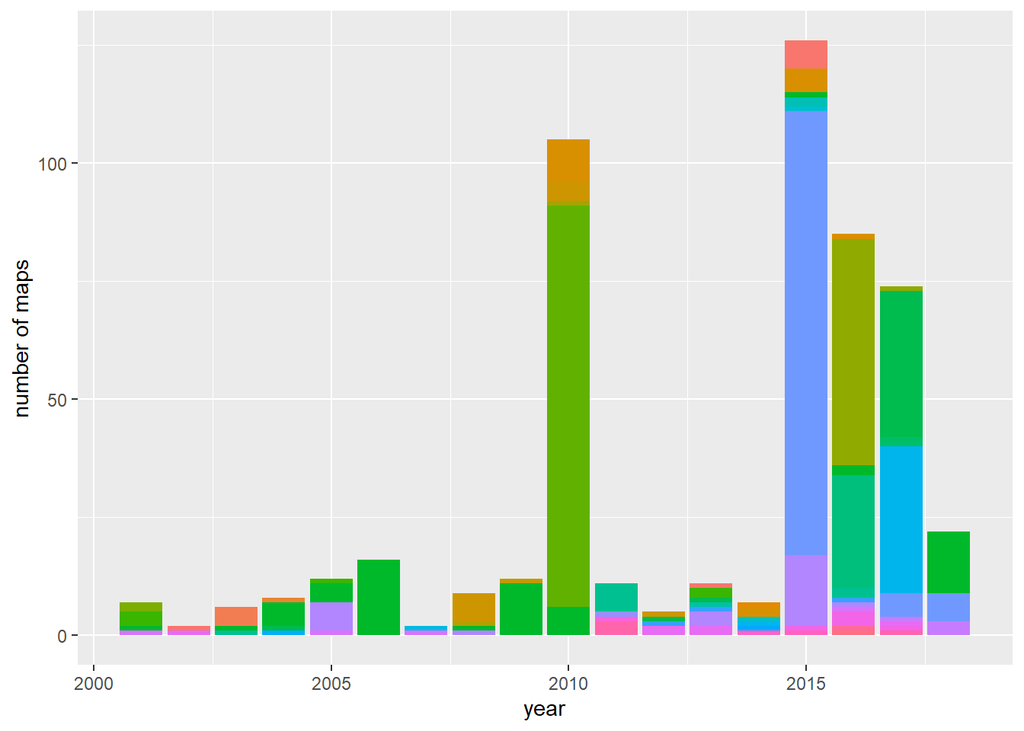

```r
# plot, fill each bar chart by country
ggplot(perc_rw,
       aes(year, n, fill=country)) +
  geom_bar(stat="identity") + theme(legend.position = "none")+
  labs(x = "year", y = "number of maps")
```

I know that there were two huge earthquakes in Haiti in 2010 and Nepal in 2015. I wonder if those big chunks for those years are because of these earthquakes. Let’s add some labels to find out.

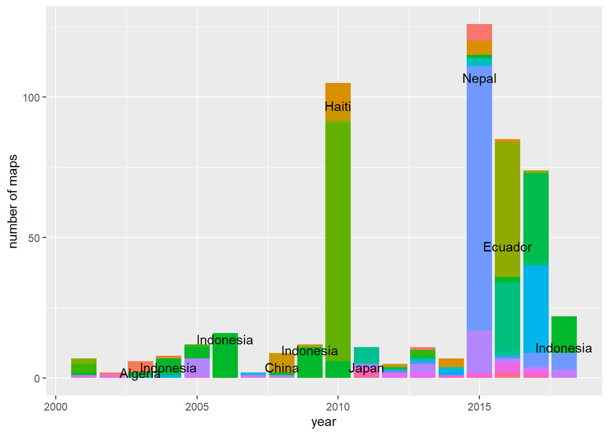

```r
# create index for events with a large percentage per year
ind <- which(perc_rw$pct > .50)
# plot, fill each bar chart by country
ggplot(perc_rw,
       aes(year, n, fill=country)) +
  geom_bar(stat="identity") + theme(legend.position = "none")+
  labs(x = "year", y = "number of maps")+
  geom_text(data = perc_rw[ind,] ,aes(year, ypos, label = country), nudge_y = -2)
```

Looks like it. It’s also interesting that the Indian ocean tsunami in 2004 didn’t seem to have that many maps. I think we have our insight here. For three relatively big earthquakes, the one that happened in 2004 didn’t have as many maps produced.

# 3 Highlighting the insight

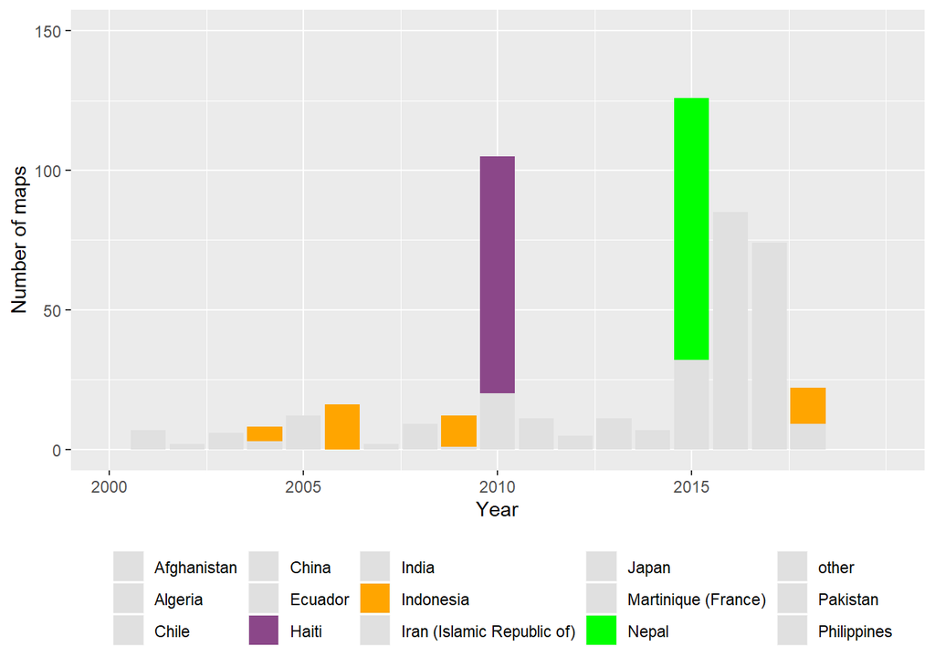

```r
perc_rw <- perc_rw %>%
  group_by(year) %>%
  mutate(country2 = country[which.max(pct)],
         country3 = country[which.max(pct)])
for (i in 1:nrow(perc_rw)) {
  # perc_rw$country2[i] <- ifelse(perc_rw$country[i] %in%perc_rw$country2[i], perc_rw$country2[i], "other")
  perc_rw$country3[i] <- ifelse(perc_rw$country[i] %in%perc_rw$country2[i], perc_rw$country2[i], "other")
}

# defining color palette
cols <- c("other" = "gray88",
          "Afghanistan" = "gray88",
          "Algeria" = "gray88",
          "Chile" = "gray88",
          "China" = "gray88",
          "Ecuador" = "gray88",
          "Haiti" = "orchid4",
          "India" = "gray88",
          "Indonesia" = "orange",
          "Iran (Islamic Republic of)" = "gray88",
          "Japan" = "gray88",
          "Martinique (France)" = "gray88",
          "Nepal" = "green",
          "Pakistan" = "gray88",
          "Philippines" = "gray88",
          "Disaster with most data" = NA)
# plot
ggplot(perc_rw,  # Calculate label positions
       aes(year, n, fill=country3)) +
  geom_bar(stat="identity")+
  # geom_text(data = text_rw,aes(x = year, y = n_maps_year, label = disaster),
  #           position = position_dodge(width = 0.0), vjust = -0.6, hjust = 0.1,
  #           check_overlap = T, angle = 0, size = 9*5/14)+
  theme(legend.position = "bottom")+
  scale_fill_manual("",values = cols)+
  scale_x_continuous(limits=c(2000, 2020), breaks = seq(2000,2015, by = 5)) +
  ylim(0,150)+
  labs(x = "Year", y = "Number of maps")
```

And now I just cleaned up a bit

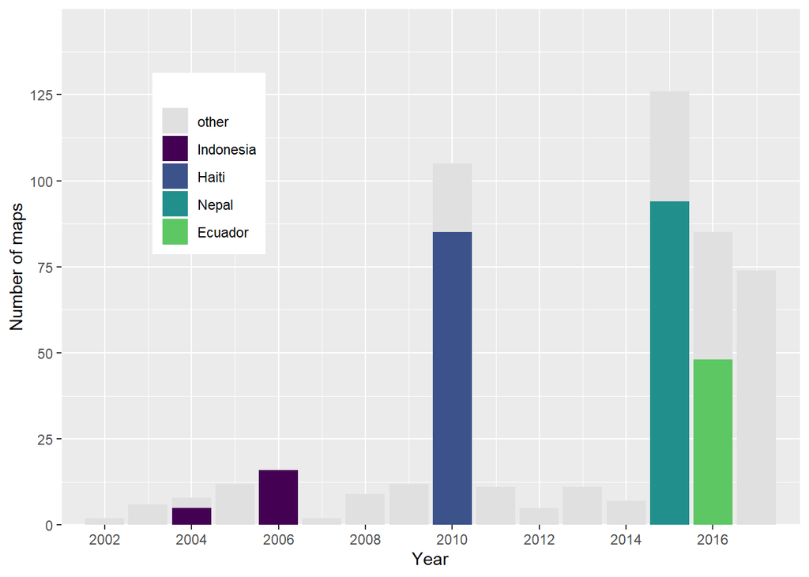

```r
perc_rw$country_labs <- perc_rw$country3
perc_rw$country_labs[which(perc_rw$country_labs %in% "Indonesia" & perc_rw$year > 2008)] <- "other"
perc_rw$country_labs[-which(perc_rw$country_labs %in% c("Indonesia","Haiti", "Nepal", "Ecuador"))] <- "other"
perc_rw$country_labs <- factor(perc_rw$country_labs, levels = c("Indonesia", "Haiti", "Nepal", "Ecuador", "other"))
perc_rw$country_labs2 <- factor(perc_rw$country_labs, levels = c("other","Indonesia", "Haiti", "Nepal", "Ecuador"))

cols <- c("Indonesia" = viridis_pal()(25)[1],
          "Haiti" = viridis_pal()(25)[7],
          "Nepal" = viridis_pal()(25)[13],
          "Ecuador" = viridis_pal()(25)[19],
          "other" = "gray88")
ggplot(perc_rw,  # Calculate label positions
       aes(year, n, group = country_labs2)) +
  geom_bar(stat="identity", aes(fill=country_labs2))+
  scale_fill_manual("",values = cols)+
  scale_x_continuous(expand = c(0, 0),limits=c(2001, 2018),
                     breaks = pretty(perc_rw$year, n = 8)[1:9]) +
  scale_y_continuous(expand = c(0, 0), limits = c(0,150),
                     breaks = seq(0,125, by = 25))+
  labs(x = "Year", y = "Number of maps")+
  theme(legend.position = c(0.2,0.7), legend.direction = "vertical")
```

# 4 Retweaking to reflect insight

## 4.1 Calculate cumulative number of disasters and plot

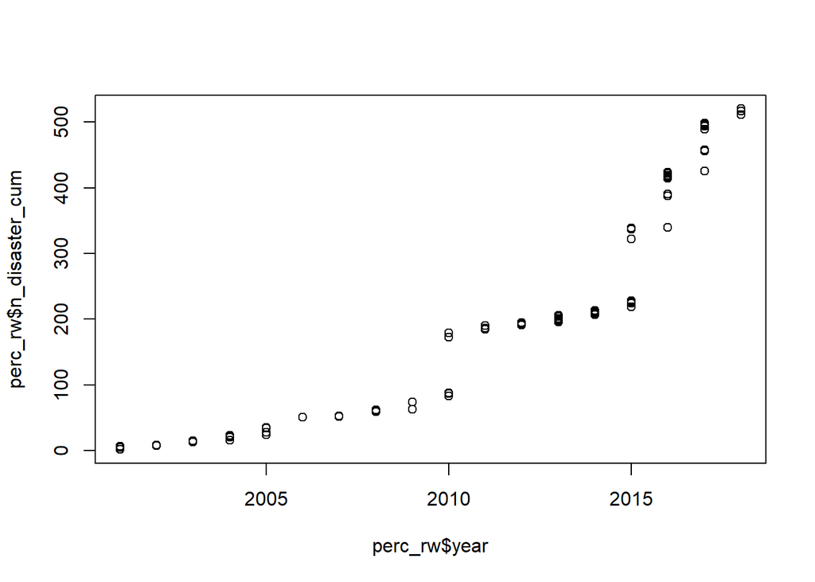

```r
perc_rw$n_disaster_cum <- cumsum(perc_rw$n)
plot(perc_rw$year, perc_rw$n_disaster_cum)
```

I also realized that I wanted to color actually by pre-2010 and post-2010 (when post-disaster data became realy en-vogue). And so I did the process all over again.

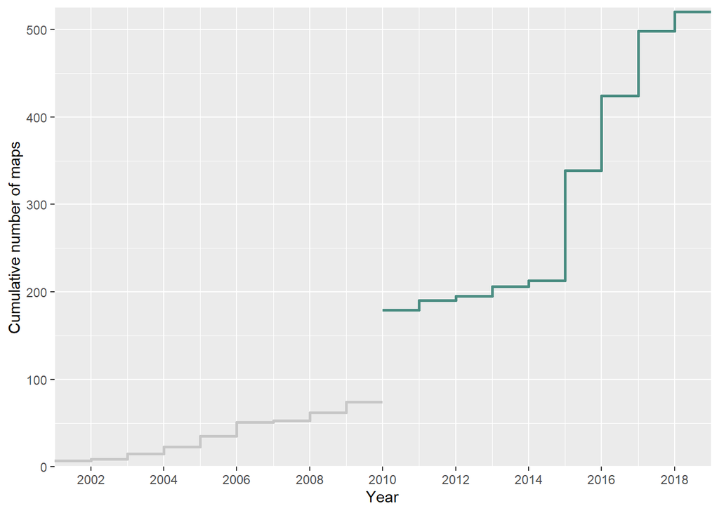

```r
cumulative_rw <- perc_rw %>% group_by(year) %>% summarise(cumulative_n = max(n_disaster_cum))
cumulative_rw$mandate <- "Pre-mandate"
cumulative_rw$mandate[cumulative_rw$year>=2010] <- "Post-mandate"

cumulative_rw_line <- rbind(cumulative_rw, cumulative_rw)
cumulative_rw_line$year[duplicated(cumulative_rw_line)] <- cumulative_rw_line$year[duplicated(cumulative_rw_line)] + 1
cumulative_rw_line <- cumulative_rw_line %>% arrange(year, cumulative_n)
cols <- c("Pre-mandate" = "gray78",
          "Post-mandate" = "#498c81")

# plot
ggplot(cumulative_rw) +
  # geom_bar(aes(x = year, y = cumulative_n, fill = mandate), stat = "identity",width = 1, position =  position_nudge(x = 0.5), alpha = 0.5)+
  geom_line(data = cumulative_rw_line,aes(x = year, y = cumulative_n,
                                          color = mandate), size = 1)+
  scale_fill_manual("", values = cols)+
  scale_color_manual("", values = cols)+
  labs(x = "Year", y = "Cumulative number of maps")+
  scale_x_continuous(expand = c(0, 0),limits=c(2001, 2019),
                     breaks = pretty(cumulative_rw$year, n = 9)) +
  scale_y_continuous(expand = c(0, 0), limits = c(0,525),
                     breaks = seq(0,500, by = 100))+
  theme(legend.position = "none", legend.direction = "vertical")
```

## 4.2 remove chart junk

We also can set a theme so that it looks better than the ggplot default (aka removing chart junk):

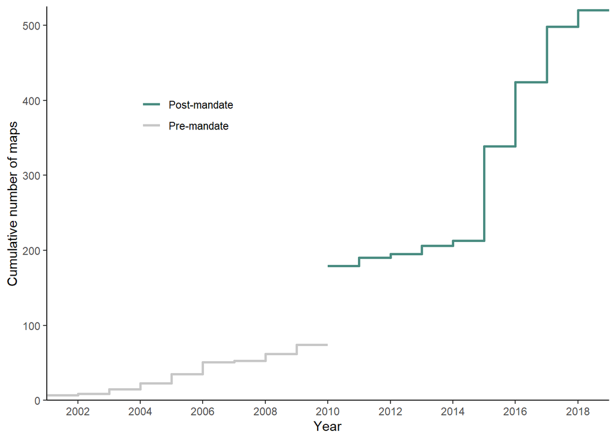

```r
# set theme
theme_set(theme_classic())
# replot
ggplot(cumulative_rw) +
  geom_line(data = cumulative_rw_line,aes(x = year, y = cumulative_n,
                                          color = mandate), size = 1)+
  scale_fill_manual("", values = cols)+
  scale_color_manual("", values = cols)+
  labs(x = "Year", y = "Cumulative number of maps")+
  scale_x_continuous(expand = c(0, 0),limits=c(2001, 2019),
                     breaks = pretty(cumulative_rw$year, n = 9)) +
  scale_y_continuous(expand = c(0, 0), limits = c(0,525),
                     breaks = seq(0,500, by = 100))+
  theme(legend.position = c(0.25, 0.75), legend.direction = "vertical")
```

This is exactly what I wanted (can add the connecting line in inkscape or illustrator)

### 4.2.1 custom themes

A note on removing chart junk. You can do so by setting a theme to a premade one (like we did in the previous chunk) or creating a theme for ggplot. Below is an example but google for more examples.

```r
plotTheme <- function(base_size = 12) {
  theme(
    plot.title = element_text(size = (base_size),colour = "black"),
    plot.subtitle = element_text(face="italic"),
    plot.caption = element_text(hjust=0),
    axis.line = element_line(colour = "black"),
    panel.background = element_blank(),
    panel.grid.major = element_blank(),
    panel.grid.minor = element_blank(),
    panel.border = element_blank(),
    strip.background = element_rect(fill = "grey80", color = "white"),
    strip.text = element_text(size=(base_size-2)),
    axis.title = element_text(size=(base_size-2)),
    axis.text = element_text(size=(base_size-2)),
    axis.title.x = element_text(hjust=1),
    axis.title.y = element_text(hjust=1),
    plot.background = element_blank(),
    legend.background = element_blank(),
    plot.margin=grid::unit(c(1,1,1,1), "mm"),
    legend.margin = margin(c(3,1,1,1)),
    legend.title = element_text(colour = "black", face = "italic"),
    legend.text = element_text(size=(base_size-2),colour = "black", face = "italic"))
}
```

Now you’re free to use! Just add it to the end of your ggplot

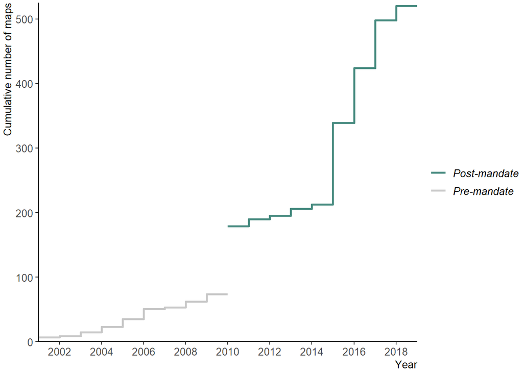

```r
ggplot(cumulative_rw) +
  geom_line(data = cumulative_rw_line,aes(x = year, y = cumulative_n,
                                          color = mandate), size = 1)+
  scale_fill_manual("", values = cols)+
  scale_color_manual("", values = cols)+
  labs(x = "Year", y = "Cumulative number of maps")+
  scale_x_continuous(expand = c(0, 0),limits=c(2001, 2019),
                     breaks = pretty(cumulative_rw$year, n = 9)) +
  scale_y_continuous(expand = c(0, 0), limits = c(0,525),
                     breaks = seq(0,500, by = 100))+
  plotTheme()
```

# 5 save

Save this graphic to pdf. This will keep it as a vector so you can edit it more directly in inkscape or illustrator. NEVER MODIFY THE DATA! Only modify all the other stuff around it

```r
ggsave(last_plot(), filename = "testplot.pdf", height = 4, width = 6.5, units = "in", dpi = 400)
```